# HCA, ontologies, shiny

Vincent J. Carey, stvjc at channing.harvard.edu

June 14, 2023

# 1 What was the interpretation of the edge thickness in the final plot of last lecture?

- use NNGraph algorithm for efficient clustering based on walktrap community detection
- cells are assigned to nodes, but graph may include edges between cells in different nodes
- the width of the edge between two nodes in the display is proportional to the ratio of the number of observed between-node edges to the expected number of between-node edges under a model of random links between cells

# 2 Online analytical processing support (OLAP)

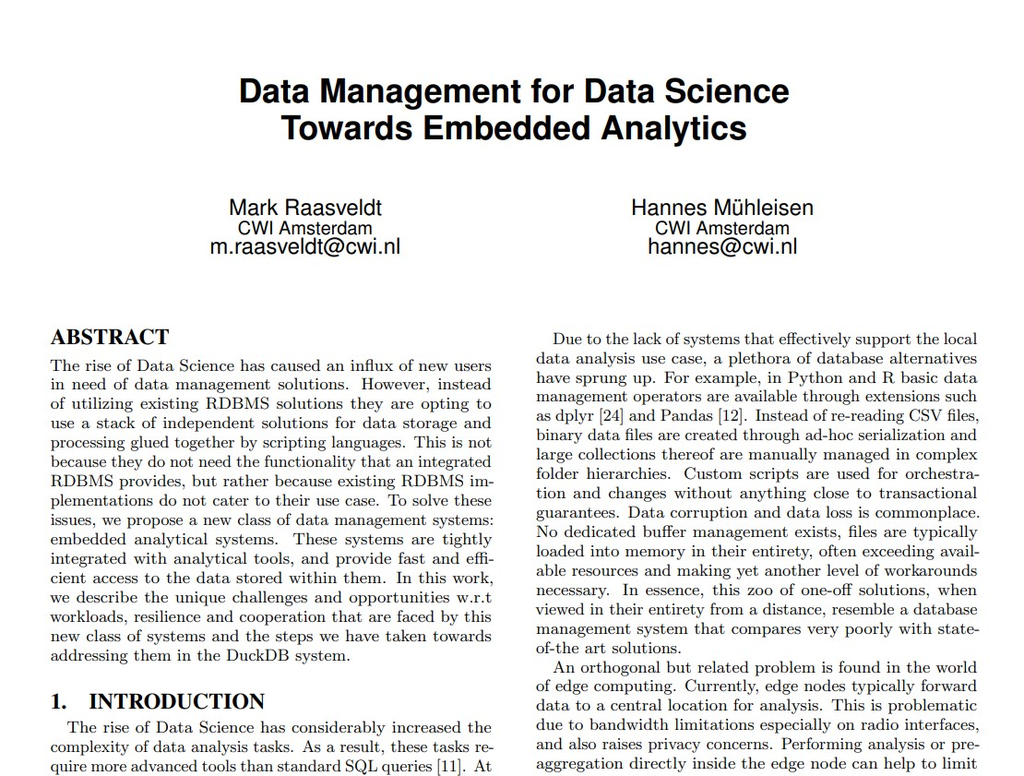

duckdb

[Full paper](https://hannes.muehleisen.org/publications/CIDR2020-raasveldt-muehleisen-duckdb.pdf)

## 2.1 motivation for a new approach

- metadata about single cells – highly repetitive, substantial role for run-length encoding or other compression schemes

## 2.2 example of CuratedAtlasQueryR

- CuratedAtlasQueryR is from WEHI institute, will appear in Bioc 3.18, and is a comprehensive reprocessing of the HumanCellAtlas with harmonized annotations

```r
library(CuratedAtlasQueryR)
md = get_metadata()
md
```

```
## # Source:   table</home/stvjc/.cache/R/CuratedAtlasQueryR/metadata.0.2.3.parquet> [?? x 56]
## # Database: DuckDB 0.8.0 [stvjc@Linux 5.15.0-73-generic:R 4.3.0/:memory:]
##    cell_              sample_    cell_type cell_type_harmonised confidence_class
##    <chr>              <chr>      <chr>     <chr>                           <dbl>
##  1 AAACCTGAGAGACGAA_1 689e2fe4f… basal ce… basal_cell                          1
##  2 AAACCTGAGTTGTCGT_1 689e2fe4f… basal ce… basal_cell                          1
##  3 AAACCTGCAGTCGATT_1 689e2fe4f… luminal … luminal_cell_of_pro…                1
##  4 AAACCTGCAGTTCATG_1 689e2fe4f… luminal … luminal_cell_of_pro…                1
##  5 AAACCTGGTCTAAACC_1 689e2fe4f… basal ce… basal_cell                          1
##  6 AAACCTGTCGTACCGG_1 689e2fe4f… basal ce… basal_cell                          1
##  7 AAACCTGTCTTGTACT_1 689e2fe4f… basal ce… basal_cell                          1
##  8 AAACGGGAGTACGTTC_1 689e2fe4f… basal ce… basal_cell                          1
##  9 AAACGGGAGTAGGTGC_1 689e2fe4f… luminal … luminal_cell_of_pro…                1
## 10 AAACGGGAGTGGGATC_1 689e2fe4f… basal ce… basal_cell                          1
## # ℹ more rows
## # ℹ 51 more variables: cell_annotation_azimuth_l2 <chr>,
## #   cell_annotation_blueprint_singler <chr>,
## #   cell_annotation_monaco_singler <chr>, sample_id_db <chr>,
## #   `_sample_name` <chr>, assay <chr>, assay_ontology_term_id <chr>,
## #   file_id_db <chr>, cell_type_ontology_term_id <chr>,
## #   development_stage <chr>, development_stage_ontology_term_id <chr>, …
```

- How it works

```r
single_cell_counts =
    md |>
    dplyr::filter(
        ethnicity == "African" &
        stringr::str_like(assay, "%10x%") &
        tissue == "lung parenchyma" &
        stringr::str_like(cell_type, "%CD4%")
    ) |>
    get_single_cell_experiment()
```

```
## ℹ Realising metadata.
```

```
## ℹ Synchronising files
```

```
## ℹ Downloading 0 files, totalling 0 GB
```

```
## ℹ Reading files.
```

```
## ℹ Compiling Single Cell Experiment.
```

- after tidyverse query:

```r
single_cell_counts
```

```
## class: SingleCellExperiment
## dim: 36229 1571
## metadata(0):
## assays(1): counts
## rownames(36229): A1BG A1BG-AS1 ... ZZEF1 ZZZ3
## rowData names(0):
## colnames(1571): ACAGCCGGTCCGTTAA_F02526_1 GGGAATGAGCCCAGCT_F02526_1 ...
##   TACAACGTCAGCATTG_SC84_1 CATTCGCTCAATACCG_F02526_1
## colData names(56): sample_ cell_type ... updated_at_y original_cell_id
## reducedDimNames(0):
## mainExpName: NULL
## altExpNames(0):
```

- Apropos shiny: Does the query above suggest some aspects of a desirable GUI? Let’s discuss.

# 3 A paper on the atlas of the prostate

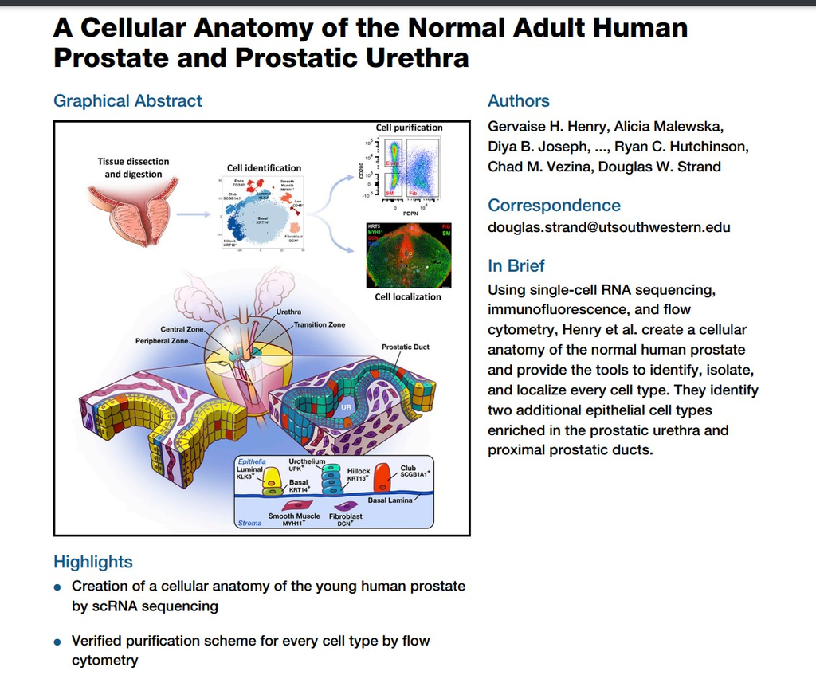

overview

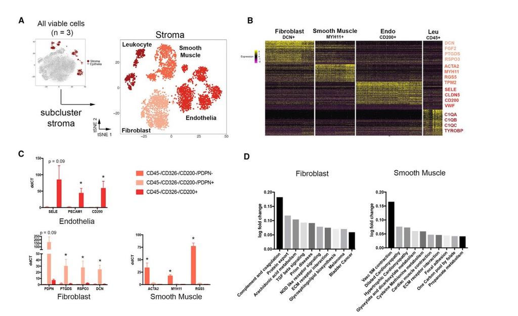

normals

## 3.1 The hca package

### 3.1.1 Surveying projects of the HCA

```r
library(hca)
p = projects()
library(DT)
datatable(as.data.frame(p))
```

|  | projectId | projectTitle | genusSpecies | sampleEntityType | specimenOrgan | specimenOrganPart | selectedCellType | libraryConstructionApproach | nucleicAcidSource | pairedEnd | workflow | specimenDisease | donorDisease | developmentStage |
| --- | --- | --- | --- | --- | --- | --- | --- | --- | --- | --- | --- | --- | --- | --- |
| 1 | 74b6d569-3b11-42ef-b6b1-a0454522b4a0 | 1.3 Million Brain Cells from E18 Mice | ['Mus musculus'] | ['specimens'] | ['brain'] | ['cortex'] | ['neuron'] | ["10x 3' v2"] | ['single cell'] | [False] | [] | ['normal'] | ['normal'] | ['mouse embryo stage'] |
| 2 | 53c53cd4-8127-4e12-bc7f-8fe1610a715c | A Cellular Anatomy of the Normal Adult Human Prostate and Prostatic Urethra | ['Homo sapiens'] | ['specimens'] | ['prostate gland'] | ['peripheral zone of prostate', 'transition zone of prostate'] | ['basal cell of prostate epithelium', 'epithelial cell of prostate', 'fibroblast of connective tissue of prostate', 'luminal cell of prostate epithelium', 'prostate epithelial cell', 'prostate stromal… | ['10X v2 sequencing'] | ['single cell'] | [False] | ['optimus_post_processing_v1.0.0', 'optimus_v4.2.3'] | ['normal'] | ['normal'] | ['human adult stage'] |
| 3 | 7027adc6-c9c9-46f3-84ee-9badc3a4f53b | A Cellular Atlas of Pitx2-Dependent Cardiac Development. | ['Mus musculus'] | ['specimens'] | ['heart'] | [] | [] | ["10X 3' v2 sequencing"] | ['single cell'] | [False] | ['optimus_post_processing_v1.0.0', 'optimus_v4.2.2'] | ['normal'] | ['normal'] | ['Theiler stage 17', 'Theiler stage 21'] |
| 4 | 94e4ee09-9b4b-410a-84dc-a751ad36d0df | A Human Liver Cell Atlas reveals Heterogeneity and Epithelial Progenitors | ['Homo sapiens'] | ['organoids', 'specimens'] | ['liver'] | [] | [] | ['CEL-seq2'] | ['single cell'] | [False] | ['analysis_protocol_normalization', 'analysis_protocol_quantification'] | ['hepatocellular carcinoma', 'normal'] | ['cholangiocarcinoma', 'colorectal cancer', 'hepatocellular carcinoma'] | ['human adult stage'] |
| 5 | c5b475f2-76b3-4a8e-8465-f3b69828fec3 | A Partial Picture of the Single-Cell Transcriptomics of Human IgA Nephropathy | ['Homo sapiens'] | ['specimens'] | ['kidney'] | [] | [] | ['GEXSCOPE technology'] | ['single cell'] | [True] | ['analysis_protocol'] | ['IgA glomerulonephritis', 'normal'] | ['IgA glomerulonephritis', 'normal'] | ['human adult stage'] |
| 6 | 60ea42e1-af49-42f5-8164-d641fdb696bc | A Protocol for Revealing Oral Neutrophil Heterogeneity by Single-Cell Immune Profiling in Human Saliva | ['Homo sapiens'] | ['specimens'] | ['oral cavity'] | ['saliva'] | ['neutrophil'] | ['Smart-seq2'] | ['single cell'] | [True] | [] | ['normal'] | ['normal'] | ['human adult stage'] |
| 7 | ef1e3497-515e-4bbe-8d4c-10161854b699 | A Single-Cell Atlas of the Human Healthy Airways. | ['Homo sapiens'] | ['specimens'] | ['bronchus', 'nose', 'trachea'] | ['epithelium of bronchus', 'epithelium of trachea', 'inferior nasal concha', 'terminal bronchus epithelium'] | [] | ["10x 3' v2"] | ['single cell'] | [False] | ['ap_matrixNormalization', 'ap_rawMatrixGeneration_hg19', 'ap_rawMatrixGeneration_hg38'] | ['normal'] | ['normal'] | ['human adult stage'] |
| 8 | 9ac53858-606a-4b89-af49-804ccedaa660 | A Single-Cell Characterization of Human Post-implantation Embryos Cultured In Vitro Delineates Morphogenesis in Primary Syncytialization | ['Homo sapiens'] | ['specimens'] | ['embryo'] | ['extraembryonic tissue'] | ['trophoblast cell'] | ['Smart-like'] | ['single cell'] | [False] | ['analysis_protocol_1', 'analysis_protocol_2'] | ['normal'] | ['normal'] | ['human embryonic stage'] |
| 9 | 258c5e15-d125-4f2d-8b4c-e3122548ec9b | A Single-Cell Transcriptome Atlas of Glia Diversity in the Human Hippocampus across the Lifespan and in Alzheimer’s Disease | ['Homo sapiens'] | ['specimens'] | ['brain'] | ['hippocampal formation'] | [] | ['SPLiT-seq'] | ['single nucleus'] | [True] | [] | ['normal'] | ['normal'] | ['adolescent', 'child stage', 'human adult stage', 'infant stage'] |
| 10 | 923d3231-7295-4184-b3f6-c3082766a8c7 | A Single-Cell Transcriptomic Atlas of Human Skin Aging. | ['Homo sapiens'] | ['specimens'] | ['skin of body'] | [] | [] | ["10x 3' v2"] | ['single cell'] | [False] | [] | ['normal'] | ['normal'] | ['adolescent stage', 'human adult stage'] |

[output cut: 340 more lines]

### 3.1.2 Picking a project; Enumerating and downloading loom files

```r
projectId = "53c53cd4-8127-4e12-bc7f-8fe1610a715c"
file_filter <- filters(
    projectId = list(is = projectId),
    fileFormat = list(is = "loom")
)
pfile = files(file_filter)
pfile$projectTitle[1]
```

```
## [1] "A Cellular Anatomy of the Normal Adult Human Prostate and Prostatic Urethra"
```

```r
#pfile |> files_download()
```

### 3.1.3 Working with loom

Very superficial filtering (to 60000 cells) and development of PCA

```r
library(LoomExperiment)
f1 = import("/home/stvjc/.cache/R/hca/36e582f7c6e_36e582f7c6e.loom")
f1
names(colData(f1))
library(scater)
sf1 = as(f1, "SingleCellExperiment")
sf1
library(scuttle)
assay(sf1[1:4,1:4])
assayNames(sf1) = "counts"
litsf1 = sf1[,1:60000]
z = DelayedArray::rowSums(assay(litsf1))
mean(z==0)
todrop = which(z==0)
litsf2 = litsf1[-todrop,]
assay(litsf2)
litsf2 = logNormCounts(litsf2)
litsf2 = runPCA(litsf2)
```

Whatchaget:

```r
if (!exists("litsf2")) load("litsf2.rda") # run code above, must have HDF5 in cache
S4Vectors::metadata(litsf2)
```

```
## $last_modified
## [1] "20210616T032315.280827Z"
##
## $CreationDate
## [1] "20210616T030548.106180Z"
##
## $LOOM_SPEC_VERSION
## [1] "3.0.0"
##
## $expression_data_type
## [1] "exonic"
##
## $input_id
## [1] "5012cf4f-ba5c-4928-aea1-ab2891e34323"
##
## $input_id_metadata_field
## [1] "sequencing_process.provenance.document_id"
##
## $input_name
## [1] "D27PrTzF_Edn"
##
## $input_name_metadata_field
## [1] "sequencing_input.biomaterial_core.biomaterial_id"
##
## $optimus_output_schema_version
## [1] "1.0.0"
##
## $pipeline_version
## [1] "Optimus_v4.2.3"
```

```
> str(litsf2) # 22MB on disk (no quantifications)
Formal class 'DelayedMatrix' [package "DelayedArray"] with 1 slot
  ..@ seed:Formal class 'DelayedAperm' [package "DelayedArray"] with 2 slots
  .. .. ..@ perm: int [1:2] 2 1
  .. .. ..@ seed:Formal class 'DelayedSubset' [package "DelayedArray"] with 2 slots
  .. .. .. .. ..@ index:List of 2
  .. .. .. .. .. ..$ : int [1:60000] 1 2 3 4 5 6 7 8 9 10 ...
  .. .. .. .. .. ..$ : int [1:23420] 13 20 22 23 31 33 34 35 36 37 ...
  .. .. .. .. ..@ seed :Formal class 'HDF5ArraySeed' [package "HDF5Array"] with 7 slots
  .. .. .. .. .. .. ..@ filepath : chr "/home/stvjc/.cache/R/hca/36e582f7c6e_36e582f7c6e.loom"
  .. .. .. .. .. .. ..@ name     : chr "/matrix"
  .. .. .. .. .. .. ..@ as_sparse: logi FALSE
  .. .. .. .. .. .. ..@ type     : chr NA
  .. .. .. .. .. .. ..@ dim      : int [1:2] 382197 58347
  .. .. .. .. .. .. ..@ chunkdim : int [1:2] 64 64
  .. .. .. .. .. .. ..@ first_val: int 0
```

```
stvjc@stvjc-XPS-13-9300:~/CSAMA_HCA$ ls -tl /home/stvjc/.cache/R/hca/36e582f7c6e_36e582f7c6e.loom
-rw-rw-r-- 1 stvjc stvjc 1206062245 Jun 21 22:37 /home/stvjc/.cache/R/hca/36e582f7c6e_36e582f7c6e.loom
```

## 3.2 Upshots

- CuratedAtlasQueryR
  - duckdb/parquet enables 40x reduction in size of metadata for harmonized HCA in CuratedAtlasQueryR
  - dplyr-like querying of resource
- easy to survey HCA with hca package
- several ways to get experiments, metadata, quantifications for projects of interest
- Once you’ve queried the atlas, iSEE accelerates exploration and elaboration of data and claims
  - check out the [voice-activated control capability](https://www.bioconductor.org/packages/devel/bioc/vignettes/iSEE/inst/doc/voice.html)

# 4 Ontologies, EBI OLS, rols (thanks Laurent Gatto!), ontoProc::ctmarks

## 4.1 rols: Basic idea

- OLS is ontology lookup service
- has API
- rols package help to interrogate the service
- ontologies are everywhere

## 4.2 Learn about ‘smooth muscle’ with rols

```r
library(rols)
ss = OlsSearch("smooth muscle", rows=100)
ss
```

```
## Object of class 'OlsSearch':
##   query: smooth muscle
##   requested: 100 (out of 50306)
##   response(s): 0
```

```r
tt = olsSearch(ss)
dd = as(tt, "data.frame")
datatable(dd)
```

|  | id | iri | short_form | obo_id | label | description | ontology_name | ontology_prefix | type | is_defining_ontology |
| --- | --- | --- | --- | --- | --- | --- | --- | --- | --- | --- |
| 1 | xao:class:http://purl.obolibrary.org/obo/XAO_0000175 | http://purl.obolibrary.org/obo/XAO_0000175 | XAO_0000175 | XAO:0000175 | smooth muscle | ['Involuntary muscle tissue consisting of uninucleate spindle-shaped fibers. Found within the walls of blood vessels, the alimentary tract, bladder, and reproductive tract.'] | xao | XAO | class | True |
| 2 | bto:class:http://purl.obolibrary.org/obo/BTO_0001260 | http://purl.obolibrary.org/obo/BTO_0001260 | BTO_0001260 | BTO:0001260 | smooth muscle | ['Muscle tissue that lacks cross striations, that is made up of elongated spindle-shaped cells having a central nucleus, and that is found in vertebrate visceral structures (as the stomach and bladder… | bto | BTO | class | True |
| 3 | zfa:class:http://purl.obolibrary.org/obo/ZFA_0005274 | http://purl.obolibrary.org/obo/ZFA_0005274 | ZFA_0005274 | ZFA:0005274 | smooth muscle | ['A non-striated muscle that is composed of spindle-shaped cells. Smooth muscle usually is organized into sheets that line cavitated organs.'] | zfa | ZFA | class | True |
| 4 | efo:class:http://www.ebi.ac.uk/efo/EFO_0000889 | http://www.ebi.ac.uk/efo/EFO_0000889 | EFO_0000889 | EFO:0000889 | smooth muscle | ['Muscle tissue that lacks cross striations, that is made up of elongated spindle-shaped cells having a central nucleus, and that is found in vertebrate visceral structures (as the stomach and bladder… | efo | EFO | class | True |
| 5 | xpo:class:http://purl.obolibrary.org/obo/XAO_0000175 | http://purl.obolibrary.org/obo/XAO_0000175 | XAO_0000175 | XAO:0000175 | smooth muscle | ['Involuntary muscle tissue consisting of uninucleate spindle-shaped fibers. Found within the walls of blood vessels, the alimentary tract, bladder, and reproductive tract.'] | xpo | XPO | class | False |
| 6 | zp:class:http://purl.obolibrary.org/obo/ZFA_0005274 | http://purl.obolibrary.org/obo/ZFA_0005274 | ZFA_0005274 | ZFA:0005274 | smooth muscle | ['A non-striated muscle that is composed of spindle-shaped cells. Smooth muscle usually is organized into sheets that line cavitated organs.'] | zp | ZP | class | False |
| 7 | wbbt:class:http://purl.obolibrary.org/obo/WBbt_0005781 | http://purl.obolibrary.org/obo/WBbt_0005781 | WBbt_0005781 | WBbt:0005781 | smooth muscle |  | wbbt | WBbt | class | False |
| 8 | wbphenotype:class:http://purl.obolibrary.org/obo/WBbt_0005781 | http://purl.obolibrary.org/obo/WBbt_0005781 | WBbt_0005781 | WBbt:0005781 | smooth muscle |  | wbphenotype | WBPhenotype | class | False |
| 9 | ncit:class:http://purl.obolibrary.org/obo/NCIT_C12437 | http://purl.obolibrary.org/obo/NCIT_C12437 | NCIT_C12437 | NCIT:C12437 | Smooth Muscle Tissue | ['Involuntary muscle tissue of the internal organs. It is composed of elongated muscle cells or fibers that are not arranged in a striated pattern and form layers of muscle tissue. The smooth muscle c… | ncit | NCIT | class | True |
| 10 | omit:class:http://purl.obolibrary.org/obo/OMIT_0010170 | http://purl.obolibrary.org/obo/OMIT_0010170 | OMIT_0010170 | OMIT:0010170 | Muscle, Smooth |  | omit | OMIT | class | True |

[output cut: 90 more lines]

## 4.3 ontoProc – capitalizing on ontologyIndex (thanks Daniel Greene!), Rgraphviz (thanks Kasper Hansen!)

```
library(ontoProc)
cl = getOnto("cellOnto")
chk = ctmarks(cl) # disappointment relative to an older version ...
```

# 5 vjcitn.shinyapps.io/ctmarks

# 6 vjcitn.shinyapps.io/gwasCatSearch

if time permits